# Modèles simples et tests d’hypothèses

Catherine Matias and Tabea Rebafka

Février 2024

## 1. Adéquation du modèle d’Erdös-Rényi

On commence par se poser la question de savoir si le modèle d’Erdös-Rényi est bien approprié pour décrire des graphes.

On rappelle que le terme ‘modèle d’Erdös-Rényi’ recouvre en fait deux versions lègèrement différentes du même principe, à savoir le modèle $G(n,p)$ qui considère l’ensemble des graphes de $n$ noeuds dans lesquels chaque arête apparaît de façon iid selon une loi $B(p)$ et le modèle $G(n,M)$ qui considère l’ensemble des graphes avec $n$ noeuds et $M$ arêtes muni de la loi uniforme. Ici, on se concentre sur le modèle $G(n,p)$.

### Modèle $G(n,p)$

La fonction `sample_gnp()` du package `igraph` permet de simuler un graphe d’Erdös-Rényi. On donne comme paramètres le nombre $n$ de noeuds et la probabilité $p$ de connection entre deux noeuds.

Simulons deux graphes différents : un faiblement connecté, et un très connecté :

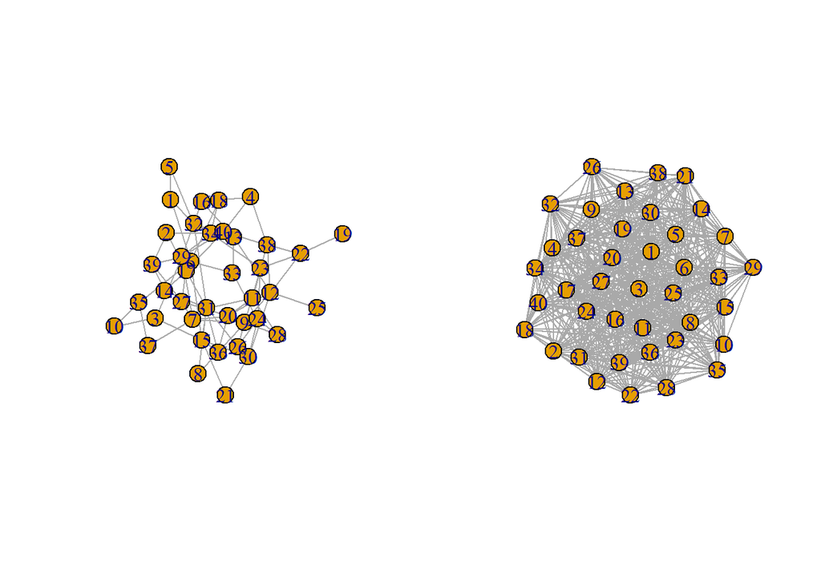

```r
set.seed(1)
n <- 40
p1 <- 0.1
p2 <- 0.7
G1 <- sample_gnp(n, p1)
G2 <- sample_gnp(n, p2)
par(mfrow = c(1, 2))
plot(G1)
plot(G2)
```

### Exercice 1

1. [Sans R] Donner un estimateur $\hat p$ de $p$ dans le modèle $G(n,p)$, et rappeler la distribution marginale du degré $D_i$ du noeud $i$ dans $G(n,p)$.

#### Réponse :

La densité est estimée par son pendant empirique, à savoir la fréquence des arêtes. Si $|E|$ est le nombre d’arêtes alors pour un graphe non dirigé on a
$$\hat p =\frac{|E|}{n(n-1)/2}.$$
Par ailleurs, la distribution marginale du degré $D_i$ est une loi binomiale $Binom(n-1,p)$.

Dans un graphe dirigé, on estime la densité par
$$\hat p_{directed} =\frac{|E|}{n(n-1)}$$
et chacune des variables aléatoires $D_i^{in},D_i^{out}$ suit également une loi binomiale $Binom(n-1,p)$.

2. Simuler des graphes $G(n,p)$ pour différentes valeurs de $n$ et de $p$. Pour chaque graphe simulé, évaluez l’estimateur $\hat p$ et comparez à $p$. De plus, tracez la distribution empirique des degrés des noeuds et superposez la distribution des degrés attendus sous le modèle $G(n,p)$. Qu’observez-vous ?

#### Réponse :

```r
n <- 100 # modifiez ce paramètre
p <- 3/n # modifiez ce rapport - graphe creux - nb d'arêtes moyen en O(n)
#p <- 0.1 #  graphe assez dense qd n grandit - nb d'arêtes moyen en O(n^2)
# p <- 5/n^2 # graphe très creux - nb d'arêtes moyen en O(1)
G <- sample_gnp(n, p)
hat_p <- 2*ecount(G)/vcount(G)/(vcount(G)-1)
error <- abs(hat_p-p)
rel_error <- abs(hat_p-p)/p
error
```

```
## [1] 0.003939394
```

```r
rel_error
```

```
## [1] 0.1313131
```

On constate que lorsque $n$ (l’ordre du graphe) augmente, l’estimateur $\hat p$ converge vers $p$. Ci-dessus le cadre considéré comme ‘le plus réaliste’ pourrait être celui d’un nombre d’arêtes en O(n). Quand le graphe devrient extrêmement creux (nb d’arêtes en O(1)), l’erreur relative peut devenir très grande.

Regardons les distributions des noeuds

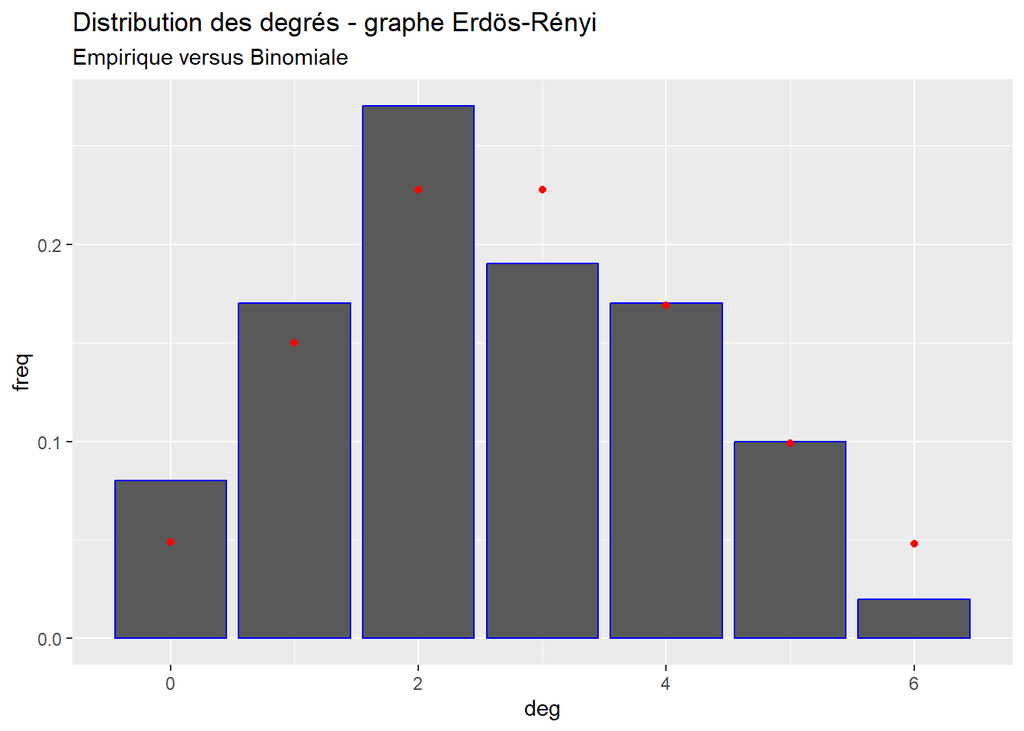

```r
degree.df <- data.frame(deg=0:max(degree(G)), freq=degree_distribution(G))
deg_plot <- ggplot(degree.df) + aes(x=deg, y=freq) + geom_bar(stat="identity",color="blue") + ggtitle("Distribution des degrés - graphe Erdös-Rényi")
# on superpose la loi theorique Binomiale
deg_plot + geom_point(aes(y=dbinom(deg, size = vcount(G)-1, prob = p)), colour="red") + labs(subtitle = "Empirique versus Binomiale")
```

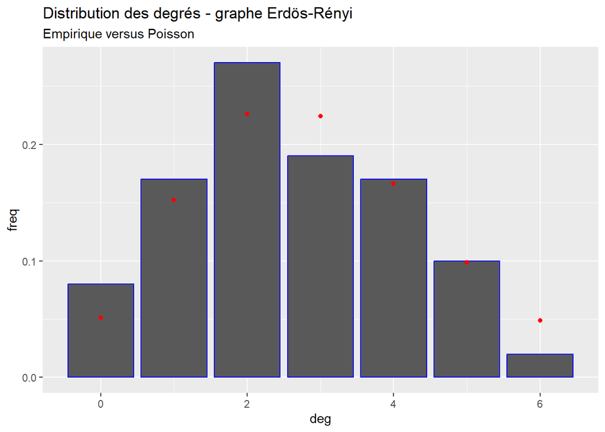

```r
# avec une approximation Poisson
deg_plot+ geom_point(aes(y=dpois(deg, lambda = (vcount(G)-1)*p)), colour="red")+ labs(subtitle = "Empirique versus Poisson")
```

Les courbes théoriques se superposent bien aux barplots empiriques (bon sur la loi Poisson, le fait de tronquer l’axe des abscisses à droite masque une partie du non-ajustement). On n’observe pas de degrés très élevé.

### Exercice 2

Reprenez un des graphes réels analysés lors du dernier TP. Quelle est la valeur estimée de $p$? Tracez la distribution empirique des degrés des noeuds et superposez la distribution des degrés attendus sous le modèle $G(n,p)$. Que constatez-vous ?

### Réponse :

On commence par le graphe Les Misérables

```r
miserab <- read_graph(file='lesmis.gml', format="gml")
n <- vcount(miserab)
M <- ecount(miserab)
hat_p <- 2*M/n/(n-1)
hat_p
```

```
## [1] 0.08680793
```

```r
edge_density(miserab)
```

```
## [1] 0.08680793
```

On obtient une fréquence d’arêtes estimée à 8,6%

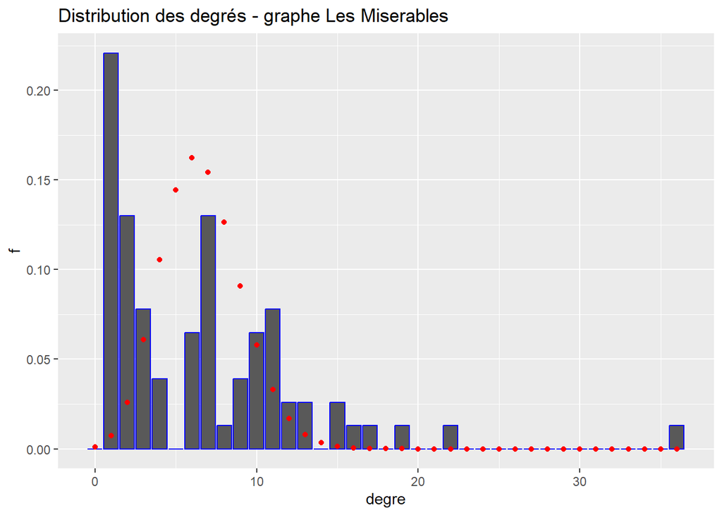

```r
mis.deg.df <- data.frame(degre=0:max(degree(miserab)), f=degree_distribution(miserab))
mis.deg.plot <- ggplot(mis.deg.df) + aes(x=degre, y=f) + geom_bar(stat="identity",color="blue") + ggtitle("Distribution des degrés - graphe Les Miserables")
# on superpose la loi theorique Binomiale - avec \hat p estimé
mis.deg.plot + geom_point(aes(y=dbinom(degre, size = n-1, prob = hat_p)), colour="red")
```

On constate que ça ne capture pas du tout les hubs, ie les quelques noeuds qui ont un degré élevé (La distribution empirique des degrés est à queue lourde). Et ça s’ajuste aussi assez mal sur le début de la distribution.

Regardons ensuite le graphe Friends (rappel : il est dirigé).

```r
friends <- read.table(file = 'Friendship-network_data_2013.csv')
G <- graph_from_data_frame(friends, directed = TRUE)
n <- vcount(G)
nb_max_darete <- choose(n, 2) * 2  ## graphe dirigé !!
hat_p <- ecount(G) / nb_max_darete
hat_p
```

```
## [1] 0.03748176
```

Pour la distribution empirique des degrés des noeuds en comparaison avec la loi binomiale $B(n,\hat p)$ on obtient (autre représentation, cette fois sans ggplot) :

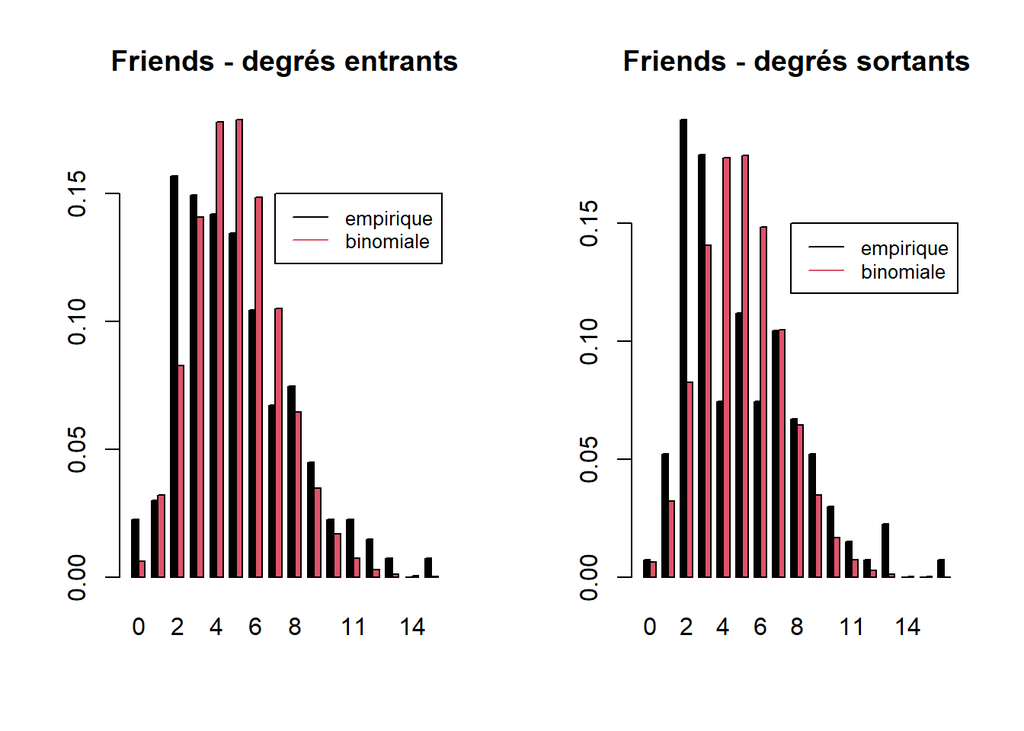

```r
Min <- max(degree(G, mode = "in"))
deg.in <- matrix(NA, ncol = Min + 1, nrow = 2)
deg.in[1,] <- degree.distribution(G, mode = 'in')
deg.in[2,] <- dbinom(0:Min, n - 1, hat_p)

Mout <- max(degree(G, mode = "out"))
deg.out <- matrix(NA, ncol = Mout + 1, nrow = 2)
deg.out[1,] <- degree.distribution(G, mode = 'out')
deg.out[2,] <- dbinom(0:Mout, n - 1, hat_p)

par(mfrow = c(1, 2))
barplot(deg.in, beside = TRUE, col = 1:2, names.arg = as.character(0:Min), main = 'Friends - degrés entrants')
legend(23, .15, c('empirique', 'binomiale'), col = 1:2, lty = 1, cex = .8)
barplot(deg.out, beside = TRUE, col = 1:2, names.arg = as.character(0:Mout), main = 'Friends - degrés sortants')
legend(25, .15, c('empirique', 'binomiale'), col = 1:2, lty = 1, cex = .8)
```

On observe que les distributions empiriques des degrés entrants et sortants atteignent leur maximum bien avant la loi binomiale. Par ailleurs, le graphe réel contient plus de degrés élevés que la loi théorique associée à $G(n,p)$. Il est alors peu probable que le graphe observé soit la réalisation d’un modèle $G(n,p)$.

## 2. Modèles de configuration

Cette fois on considère la famille des modèles de configuration.

### Exercice 3

On commence par ajuster une loi de puissance sur le graphe utilisé à l’exercice précédent. Utilisez pour cela la fonction ‘fit_power_law’ (commencez par lire l’aide pour comprendre son fonctionnement). Puis représentez la distribution empirique des degrés et superposez la loi de puissance avec le paramètre estimé. Attention à la constante de normalisation !

### Réponse :

La fonction ajuste une loi de puissance sur la distribution des degrés empiriques. Mais attention car la loi de puissance n’est pas définie en 0, donc si vous avez des noeuds isolés il faut penser à les enlever !

```r
#help("fit_power_law")
adjust <- fit_power_law(degree(miserab))
adjust
```

```
## $continuous
## [1] FALSE
##
## $alpha
## [1] 4.125169
##
## $xmin
## [1] 10
##
## $logLik
## [1] -53.66989
##
## $KS.stat
## [1] 0.05144563
##
## $KS.p
## [1] 1
```

L’estimateur de l’exposant de la loi de puissance est $\alpha=4.1$. Représentons les distributions empiriques et estimées des degrés. Là encore, il faut faire attention à ne pas commencer en 0 sinon la loi de puissance explose et on ne voit rien.

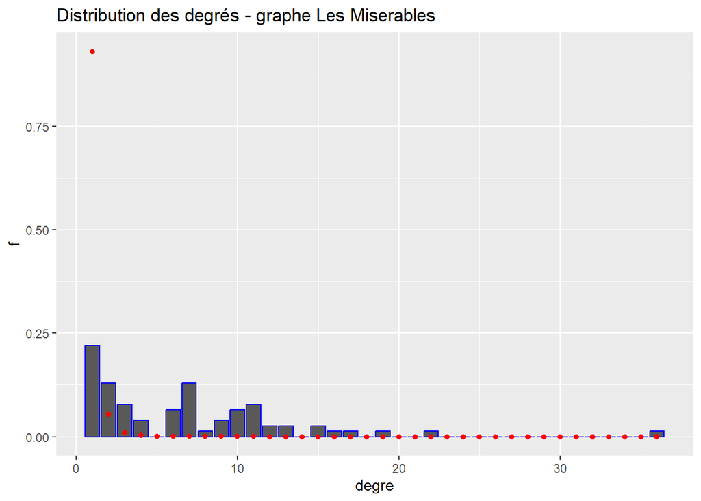

```r
mis.deg.no0.df <- data.frame(degre=1:max(degree(miserab)), f=degree_distribution(miserab)[-1])
mis.deg.plot <- ggplot(mis.deg.no0.df) + aes(x=degre, y=f) + geom_bar(stat="identity",color="blue") + ggtitle("Distribution des degrés - graphe Les Miserables")
# On écrit une fonction qui donne la densité de la loi de puissance sur 1:(n-1).
power.dens <- function(x, alpha,n){
  norm <- 1/sum((1:(n-1))^(-alpha)) # constante de normalisation pour que la somme vaille 1
  return(norm*x^(-alpha))
}
# on superpose la loi theorique puissance - avec alpha estimé
mis.deg.plot +geom_point(aes(y=power.dens(degre, alpha = adjust$alpha, n=vcount(miserab))), colour="red")
```

Sur ce jeu de données, la distribution des degrés ne suit pas du tout une loi de puissance.

### Exercice 4

On considère le modèle random-degree $RD(\underline{d})$ où $\underline{d}$ est la suite des degrés du graphe observé. Comparez la valeur observée du degré $d_i$ et la valeur moyenne $\mathbb{E}(D_i)$ sous le modèle $RD(\underline{d})$ (pour différents choix de la constante multiplicative).

### Réponse :

Dans la loi $RD(\underline d)$, chaque entrée $A_{ij}$ de la matrice d’adjacence suit une loi $B(p_{ij})$ avec $p_{ij}=d_id_j/C$ pour un certain choix $C$ de constante, qui sert à faire en sorte que tous les $p_{ij}\leq 1$. De plus, l’espérance $\mathbb{E}(D_i)$ vaut $d_i(2|E|-d_i)/C$.

On commence par choisir $C=\max(d_id_j)$.

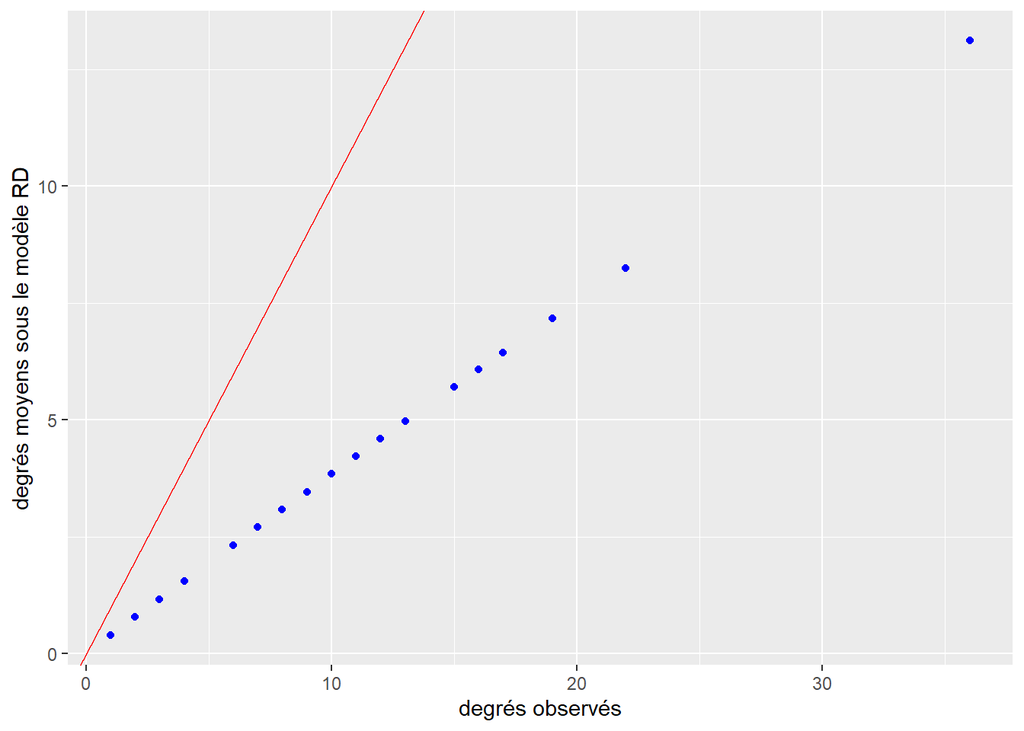

```r
# On utilise outer pour calculer les produits croisés d_id_j
d.seq <- degree(miserab)
p.ij <- outer(d.seq,d.seq)
# Choix de C
C <- max(p.ij)
esp.d.seq <- d.seq*(2*M-d.seq)/C
plot.df <- data.frame(d.seq=d.seq,esp.d.seq=esp.d.seq)
ggplot(data=plot.df)+ aes(x=d.seq,y=esp.d.seq) + geom_point(col="blue") + geom_abline(intercept = 0, slope = 1, color="red") +labs(x="degrés observés", y="degrés moyens sous le modèle RD")
```

Avec ce choix de normalisation, ça ne s’ajuste pas. On essaye $C=2|E|$.

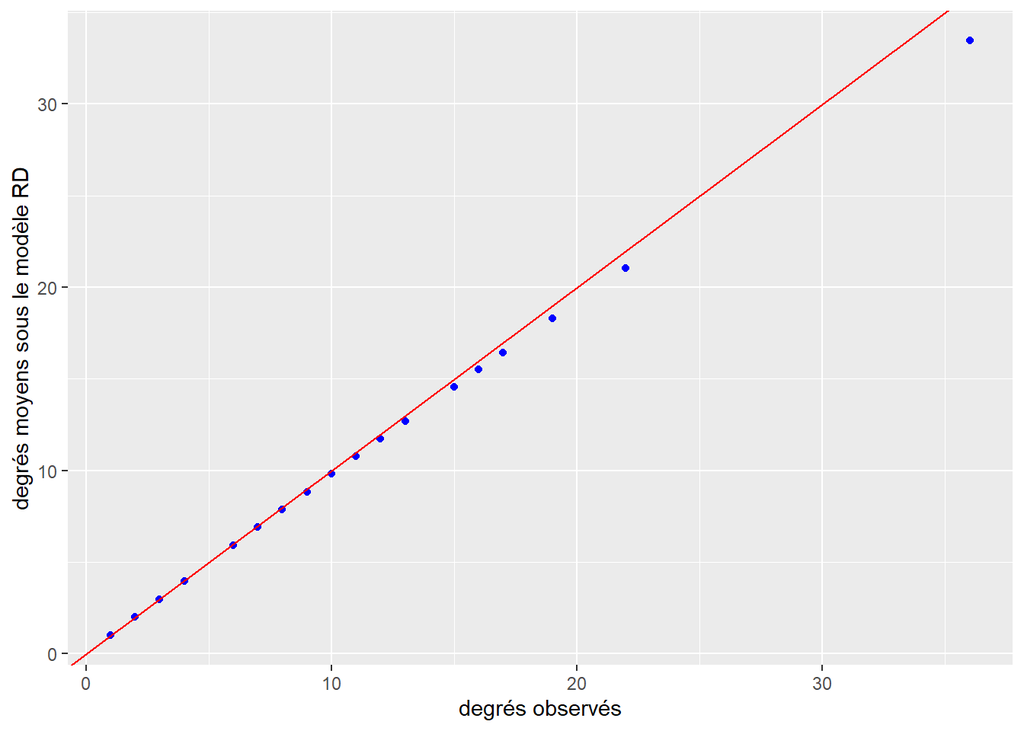

```r
# Choix de C
C<- 2*M
esp.d.seq <- d.seq*(2*M-d.seq)/C
plot.df <- data.frame(d.seq=d.seq,esp.d.seq=esp.d.seq)
ggplot(data=plot.df)+ aes(x=d.seq,y=esp.d.seq) + geom_point(col="blue") + geom_abline(intercept = 0, slope = 1, color="red")  +labs(x="degrés observés", y="degrés moyens sous le modèle RD")
```

Cette fois c’est beaucoup ieux : on voit que les degrés observés et attendus en moyenne sous le modèle coïncident presque.

## 3. Tests

On va se servir des modèles de configuration pour mettre en oeuvre des tests simples sur les statistiques d’un graphe.

### Exercice 4

1. Ecrivez deux fonctions de simulation de graphes sous le modèle à degrés fixés $FD(\underline d)$ avec les algorithmes de matching et de re-branchement.
2. Reprenez un de vos exemples réels : utilisez les deux fonctions pour générer des graphes qui ont la même suite de degrés que votre graphe réel. On pourra comparer le nombre de triangles dans les deux graphes, ou toute autre statistique de votre choix. Commentez.
3. On veut tester si le nombre d’occurrences du triangle dans le graphe observé est significativement trop grand ou trop petit par rapport à la valeur attendue sous le modèle nul $FD(\underline d)$. On utilise pour cela des simulations de Monte-Carlo. Plus précisément, on génère un grand nombre de graphes ayant la même suite de degrés et on compte le nombre de triangles pour chacun d’eux. Pour générer ces graphes, est-il raisonnable d’utiliser les algorithmes de matching et de re-branchement que vous avez codé ? Si non utilisez directement le package `igraph`. Tracez un histogramme de cette distribution. Que pensez-vous de la valeur observée dans votre graphe réel?

### Réponse :

```r
# Algorithme de matching
match.gen <- function(d){
    # Initialisation
    n <- length(d)
    l <- sum(d)
    Edge.List <- list()
    Fake.Nodes <- c()
    loop.test <- T
    multi.test <- T

    # Creation de la liste des noeuds etendue
    for (i in 1:n){
        Fake.Nodes <- c(Fake.Nodes,rep(i,d[i]))
        }

    # a faire tant qu'on a pas obtenu un graphe
    while (max(loop.test==T, multi.test==T)==1){
        # On tire des aretes
        ind <- 0
        while (l >= 1){
            ind <- ind+1
            u <- sample(1:l,2)
            u <- sort(u)        # pratique d'ordonner les indices pour la suite
            if (Fake.Nodes[u[1]]==Fake.Nodes[u[2]]) {  # est-ce une boucle ?
                loop.test <- T
                break
                }
            else {
                loop.test <- F
                Edge.List[[ind]] <- Fake.Nodes[u]
                Fake.Nodes <- Fake.Nodes[-u]
                l <- l-2
                }
            }

        # Test des aretes doubles
        # Attention fonctionne avec des aretes ordonnées !
        multi.test <- as.logical(1-( length(unique(Edge.List)) == ind ))
    }

    return(Edge.List)
}

# test de la fonction match.gen
# d <- c(4,2,3,1,0,1,1)
# is_degseq(d) # verifions que c'est bien une suite de degrés
# try1 <- match.gen(d) # ca plante souvent !!!
# d<-c(1,1,1,1)
# is_degseq(d)
# try2 <- match.gen(d) # ca plante souvent !!!
# # sur des données réelles
# d <- degree(miserab)
# is_degseq(d)
# try3 <- match.gen(d)


# Algorithme de rewiring
# uniquement pour des graphes non orientés ici !
# Edge.List est un tableau avec nb de lignes= nb d'arêtes et 2 colonnes
rewire.gen<-function(Edge.List,Nb.iter=100*(dim(Edge.List)[1])){
    l <- dim(Edge.List)[1]
    Edge.List <- t(apply(Edge.List,1,sort))
    for (i in 1:Nb.iter){
        u <- sample(1:l,2)
        old1 <- Edge.List[u[1],]
        old2 <- Edge.List[u[2],]
        new1 <- sort(c(old1[1],old2[2]))
        new2 <- sort(c(old1[2],old2[1]))
        # On vérifie qu'il y a 4 noeuds différents (sinon soit on cree une boucle, soit on ne fait rien, et que les nouvelles aretes n'existent pas deja)
        if ((length(unique(c(old1,old2)))==4) && (length(unique(rbind(Edge.List[-c(u[1],u[2]),], new1, new2)))==l )){
            Edge.List[u[1],] <- new1
            Edge.List[u[2],] <- new2
            }
        }
    return(Edge.List)
}

# test
# test<- as.matrix(friends)
# rewire.gen(test)
# retry<- rewire.gen(try1)
```

Les fonctions qu’on a écrites ne sont pas optimisées, il est préférable d’utiliser la fonction ‘sample_degseq’ de igraph. Attention aux options de cette fonction, par défaut, elle crée des graphes avec potentiellement des boucles et des arêtes multiples. La méthode la plus efficace est ‘vl’ (algorithme de Viger et Latapy).

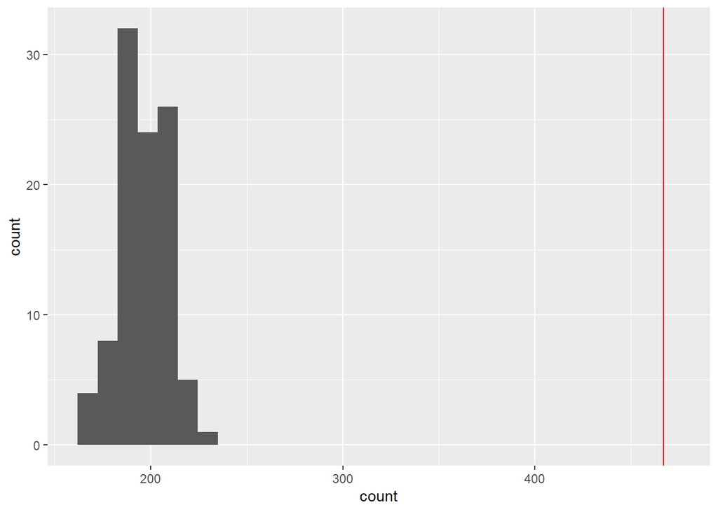

```r
deg.seq<- degree(miserab)
#help("sample_degseq")
R <- 100 # réplicats Monte Carlo
T <- rep(NA,R)
for (i in 1:R){
  G <- sample_degseq(deg.seq, method="vl")
  T[i]<- sum(count_triangles(G))/3
}
ggplot(data.frame(count=T))+ aes(count)+geom_histogram() +geom_vline(xintercept=sum(count_triangles(miserab))/3,col="red")
```

Ici le nombre de triangles qu’on observe ne s’explique pas du tout avec la loi $FD$ sur les degrés !

## 4. Attachement préférentiel

### Exercice 6

Voici le code pour générer la matrice d’adjacence par attachement préférentiel.

```r
sample_attach_pref <- function(n0, p0, m, nb.it){
  # ARGUMENTS :
  # n0 - nb de noeuds du graphe initial
  # p0 - probabilité du G(n0,p0) initial
  # m - nb d'arêtes à ajouter à chaque itérations
  # nb.it - nb d'itérations de l'algo

  # Générer un graphe initial G(n0,p0)
  G <- sample_gnp(n0, p0)

  for (t in 1:nb.it){
   # tirer m noeuds avec des proba proportionnelles aux degrés des noeuds
   ind <- sample(1:vcount(G), m, replace = FALSE, degree(G))
   # ajouter le nouveau noeud et les nouvelles arêtes au graphe
   G <- add_vertices(G, 1)
   G <- add.edges(G, matrix(c(rep(vcount(G), m), ind), nrow = 2, byrow = TRUE))
  }
  return(G)
}
```

Voyons ce que ça donne sur un petit exemple

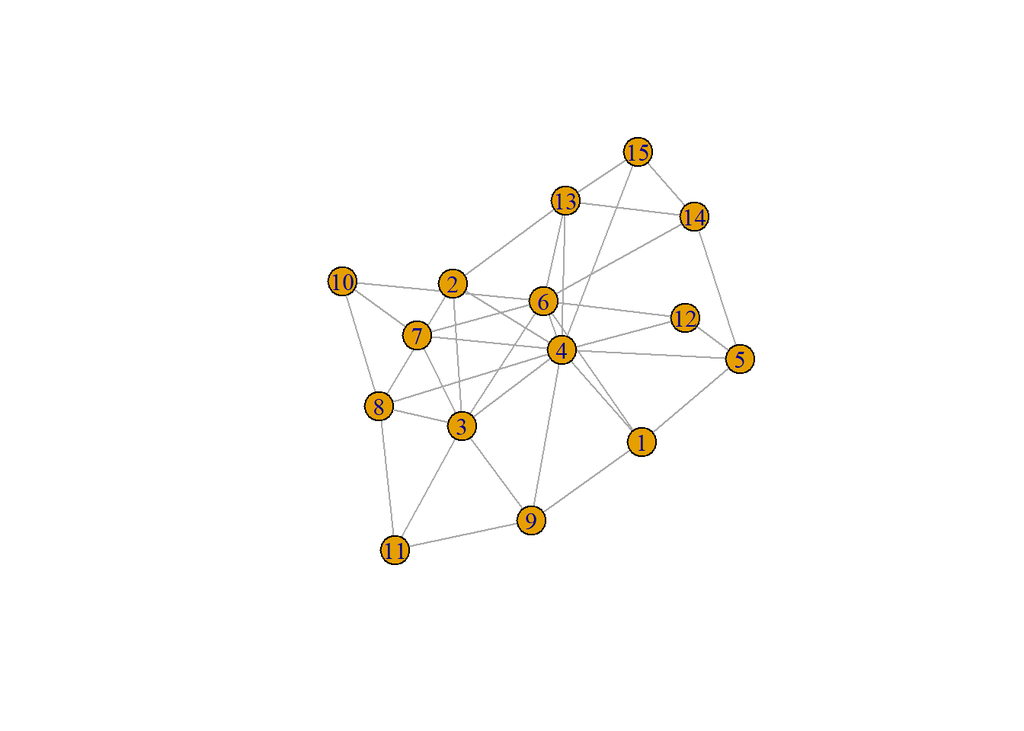

```r
set.seed(2)
G <- sample_attach_pref(5, .5, 3, 10)
plot(G)
```

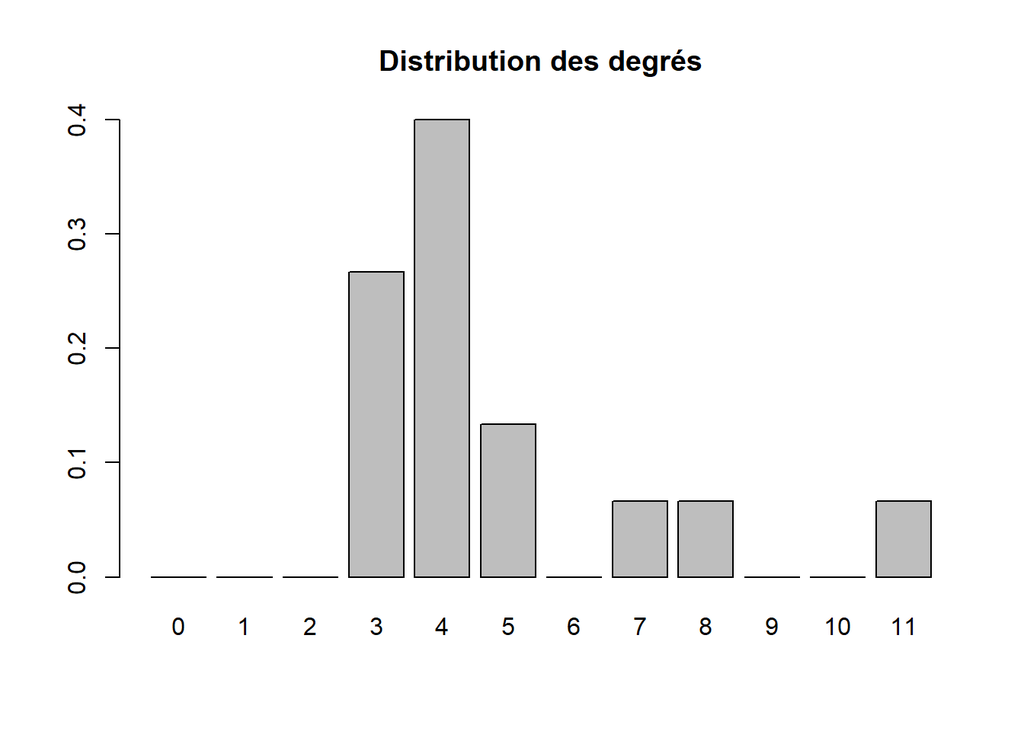

```r
degres <- degree.distribution(G)
barplot(degres, names.arg = as.character(0:max(degree(G))),
        main = 'Distribution des degrés')
```

Le graphe initial est relativement dense (car $p=0.5$) et on ajoute toujours des noeuds de degrés $m=3$. Par conséquent, le graphe final contient beaucoup de noeuds de degrés au moins 3.

Si on fait plus d’itérations :

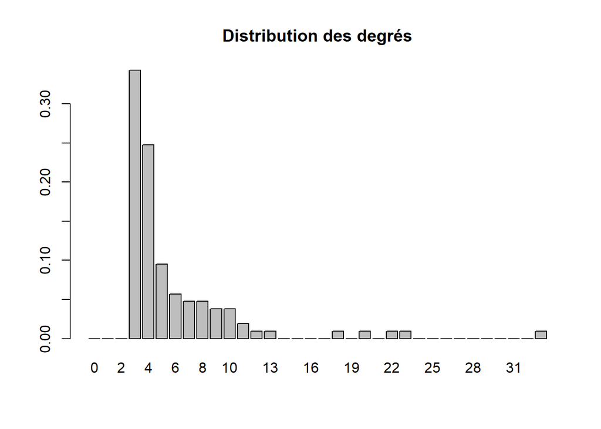

```r
G <- sample_attach_pref(5, .5, 3, 100)
degres <- degree.distribution(G)
barplot(degres, names.arg = as.character(0:max(degree(G))),
        main = 'Distribution des degrés')
```

Quelques noeuds se détachent des autres et deviennent des noeuds fortement connectés.

Si on fait encore plus d’itérations :

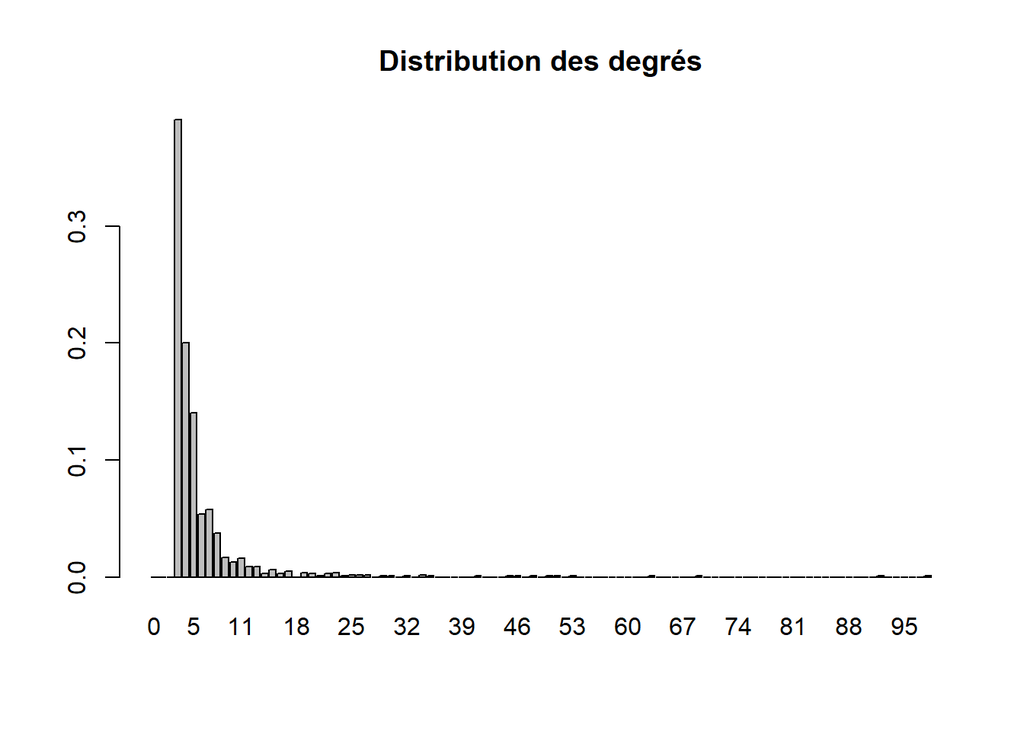

```r
G <- sample_attach_pref(5, .5, 3, 1000)
degres <- degree.distribution(G)
barplot(degres, names.arg = as.character(0:max(degree(G))),
        main = 'Distribution des degrés')
```

La distribution de degrés des noeuds ressemble à une loi de puissance : la plupart de noeuds sont faiblement connectés, et il y a quelques hubs dans le graphe.

Jouons avec les paramètres du graphe initial. Augmentons d’abord l’ordre du graphe initial :

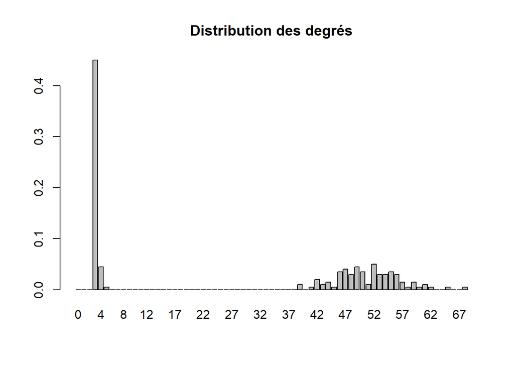

```r
G <- sample_attach_pref(100, .5, 3, 100)
degres <- degree.distribution(G)
barplot(degres, names.arg = as.character(0:max(degree(G))),
        main = 'Distribution des degrés')
```

Le degré moyen du graphe initial étant relativement élevé (environ $n_0p_0=100*0.5=50$) par rapport au degré $m$ des nouveaux noeuds ajoutés au fil de l’algorithme, on distingue facilement deux groupes de noeuds : ceux qu’on vient d’ajouter dans les itérations sont à degré très faibles, les autres sont les noeuds du graphe initial.

Que se passe-t-il quand on fait plus d’itérations :

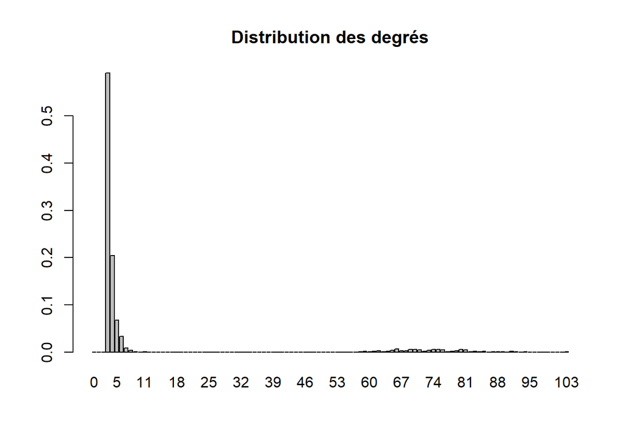

```r
G <- sample_attach_pref(100, .5, 3, 1000)
degres <- degree.distribution(G)
barplot(degres, names.arg = as.character(0:max(degree(G))),
        main = 'Distribution des degrés')
```

On distingue toujours très clairement les deux groupes de noeuds (initiaux et ceux des itérations). Les noeuds ajoutés au fil du temps n’arrivent pas à “rattraper” les noeuds intiaux en termes de degrés.

Diminuons la probabilité $p$ du graphe $G(n,p)$ initial.

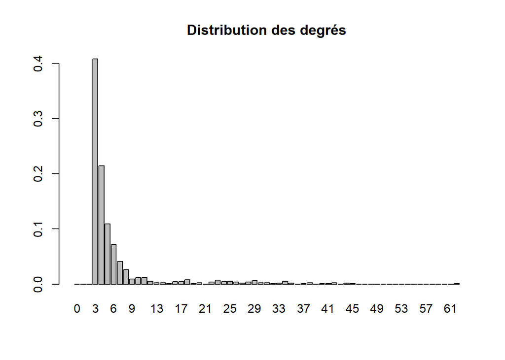

```r
G <- sample_attach_pref(100, .1, 3, 1000)
degres <- degree.distribution(G)
barplot(degres, names.arg = as.character(0:max(degree(G))),
        main = 'Distribution des degrés')
```

Ici on ne peut pas distinguer les deux groupes de noeuds, et la distribution des degrés de noeuds ressemble à une loi de puissance.

Voyons l’effet du choix du nombre $m$ d’arêtes à ajouter au graphe à chaque itération :

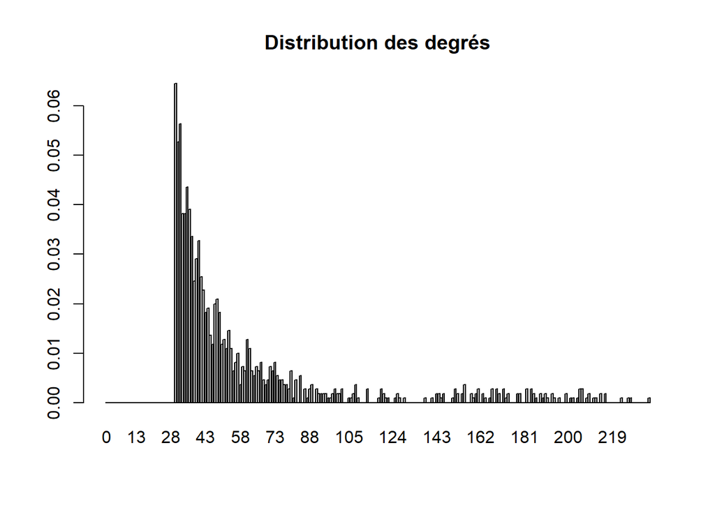

```r
G <- sample_attach_pref(100, .5, 30, 1000)
degres <- degree.distribution(G)
barplot(degres, names.arg = as.character(0:max(degree(G))),
        main = 'Distribution des degrés')
```

Bien qu’on soit parti d’un graphe initial relativement dense ($p=0.5$), on ne peut pas distinguer deux groupes de noeuds et la distribution des degrés des noeuds ressemble à une loi de puissance.

On a l’impression qu’il faut que $m$ soit de l’ordre du degré moyen du graphe initial, pour que les noeuds ajoutés “se mélangent” avec les noeuds initiaux en termes de degrés et la distribution des degrés de noeuds ressemble à une loi de puissance. Autrement, on pourra toujours distinguer deux groupes: les noeuds du graphe initial et les noeuds ajoutés dans les itérations.